# 4 Terms

Rushabh Barbhaya

2020-11-21

## Terminology Practice Assignment

We are going to use an example from the `lavaan` tutorials, which you can find at https://lavaan.ugent.be/tutorial/sem.html. The model represents a complex model that will allow you to think about some of the terminology covered in the lecture.

Here’s a picture of the model:

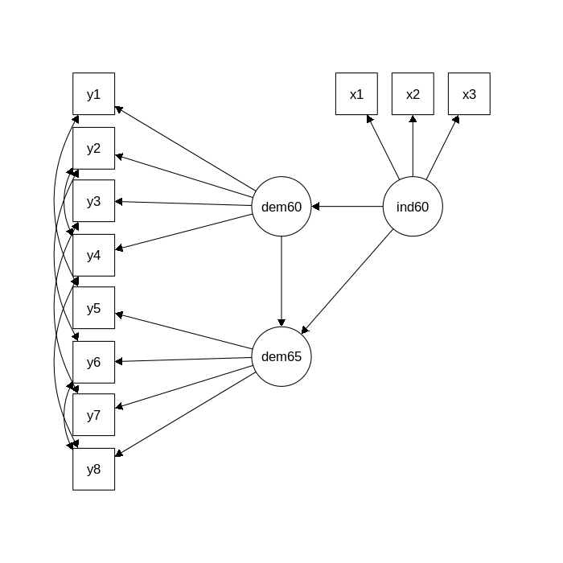

SEM Example

We have not covered yet how to write the model code, but you can see it below.

```r
library(lavaan)
model <- '
  # measurement model
    ind60 =~ x1 + x2 + x3
    dem60 =~ y1 + y2 + y3 + y4
    dem65 =~ y5 + y6 + y7 + y8
  # regressions
    dem60 ~ ind60
    dem65 ~ ind60 + dem60
  # residual correlations
    y1 ~~ y5
    y2 ~~ y4 + y6
    y3 ~~ y7
    y4 ~~ y8
    y6 ~~ y8
'
fit <- sem(model, data=PoliticalDemocracy)
```

## Understanding Terminology

QUESTION: How many latent variables are in the model? ANSWER: 3

QUESTION: How many manifest variables are in the model? ANSWER: 11

QUESTION: What would you label `ind60` predicting `x1`, `x2`, and `x3`? ANSWER: Measurement Model

QUESTION: What would you label `ind60` predicting `dem60` and `dem65`? ANSWER: Structural Model

QUESTION: Is `ind60` an endogenous or exogenous variable? ANSWER: Exogenous

QUESTION: Is `dem60` an endogenous or exogenous variable? ANSWER: Both

## Understanding Identification

Here’s a visualization of the model using `semPlot`, which shows you all the estimated paths.

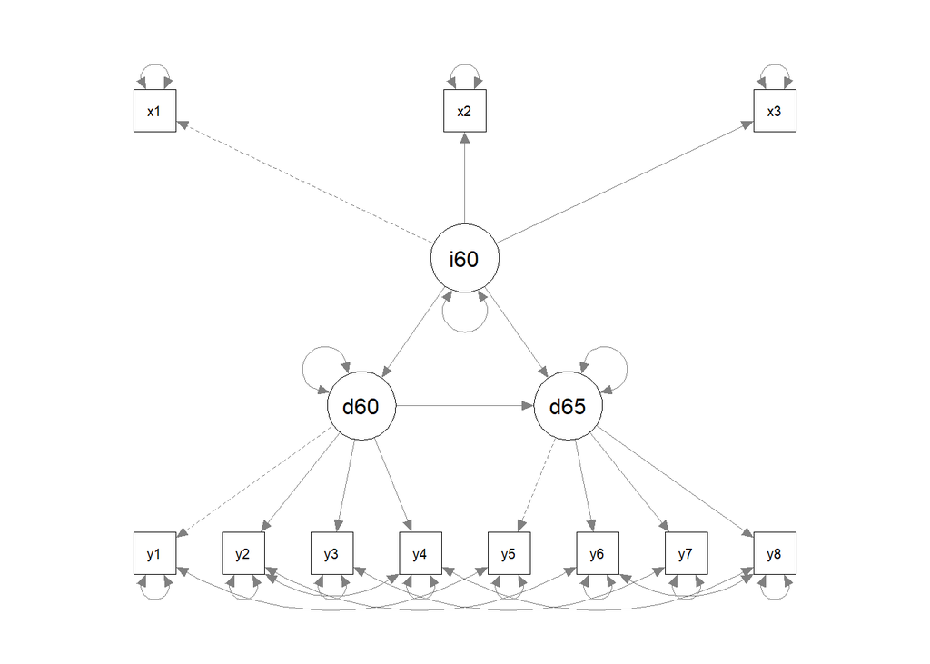

```r
library(semPlot)
semPaths(fit)
```

QUESTION: How many variances (error/latent variable) are estimated? ANSWER: 14

QUESTION: How many regressions are estimated? ANSWER: 3

QUESTION: How many loadings are estimated? ANSWER: 8

QUESTION: How many covariances are estimated? ANSWER: 6

QUESTION: How many *possible* parameters can you estimate? ANSWER: 66

QUESTION: How many *parameters* are you estimating? (add variances, regressions, loadings, covariances) ANSWER: 31

QUESTION: Given the previous two answers, what is the *df* for your model? ANSWER: 35

You can check your work against the model summary provided below. It’s ok if you get it wrong! Learning how to read model diagrams and know what to expect is an important part of learning SEM.

```r
summary(fit)
```

```
## lavaan 0.6-7 ended normally after 68 iterations
##
##   Estimator                                         ML
##   Optimization method                           NLMINB
##   Number of free parameters                         31
##
##   Number of observations                            75
##
## Model Test User Model:
##
##   Test statistic                                38.125
##   Degrees of freedom                                35
##   P-value (Chi-square)                           0.329
##
## Parameter Estimates:
##
##   Standard errors                             Standard
##   Information                                 Expected
##   Information saturated (h1) model          Structured
##
## Latent Variables:
##                    Estimate  Std.Err  z-value  P(>|z|)
##   ind60 =~
##     x1                1.000
##     x2                2.180    0.139   15.742    0.000
##     x3                1.819    0.152   11.967    0.000
##   dem60 =~
##     y1                1.000
##     y2                1.257    0.182    6.889    0.000
##     y3                1.058    0.151    6.987    0.000
##     y4                1.265    0.145    8.722    0.000
##   dem65 =~
##     y5                1.000
##     y6                1.186    0.169    7.024    0.000
##     y7                1.280    0.160    8.002    0.000
##     y8                1.266    0.158    8.007    0.000
##
## Regressions:
##                    Estimate  Std.Err  z-value  P(>|z|)
##   dem60 ~
```

[output cut: 20 more lines]

```
##                    Estimate  Std.Err  z-value  P(>|z|)
##    .x1                0.082    0.019    4.184    0.000
##    .x2                0.120    0.070    1.718    0.086
##    .x3                0.467    0.090    5.177    0.000
##    .y1                1.891    0.444    4.256    0.000
##    .y2                7.373    1.374    5.366    0.000
##    .y3                5.067    0.952    5.324    0.000
##    .y4                3.148    0.739    4.261    0.000
##    .y5                2.351    0.480    4.895    0.000
##    .y6                4.954    0.914    5.419    0.000
##    .y7                3.431    0.713    4.814    0.000
##    .y8                3.254    0.695    4.685    0.000
##     ind60             0.448    0.087    5.173    0.000
##    .dem60             3.956    0.921    4.295    0.000
##    .dem65             0.172    0.215    0.803    0.422
```